# Final R Exercise

Catherine Yang

9/19/2019

## Task 1: Import the data

```r
library(readr)
library(dplyr)
setwd("..")

# Read in data
schools <- read_csv("data/nys_schools.csv")
counties <- read_csv("data/nys_acs.csv")
```

## Task 2: Explore the data

**Getting to know your data is a critical part of data analysis. Take the time to explore the structure of the two dataframes you have imported. What types of variables are there? Is there any missing data? How can you tell? What else do you notice about the data?**

First, look at the the `schools` data.

```r
# Explore the datatypes, df dimensions, etc.
str(schools)
```

```
## Classes 'spec_tbl_df', 'tbl_df', 'tbl' and 'data.frame': 35663 obs. of  12 variables:
##  $ school_cd        : chr  "010100010014" "010100010014" "010100010014" "010100010014" ...
##  $ school_name      : chr  "MONTESSORI MAGNET SCHOOL" "MONTESSORI MAGNET SCHOOL" "MONTESSORI MAGNET SCHOOL" "MONTESSORI MAGNET SCHOOL" ...
##  $ district_name    : chr  "ALBANY CITY SCHOOL DISTRICT" "ALBANY CITY SCHOOL DISTRICT" "ALBANY CITY SCHOOL DISTRICT" "ALBANY CITY SCHOOL DISTRICT" ...
##  $ county_name      : chr  "ALBANY" "ALBANY" "ALBANY" "ALBANY" ...
##  $ region           : chr  "CAPITAL DISTRICT" "CAPITAL DISTRICT" "CAPITAL DISTRICT" "CAPITAL DISTRICT" ...
##  $ year             : num  2008 2009 2010 2011 2012 ...
##  $ total_enroll     : num  316 312 300 326 294 321 335 347 366 359 ...
##  $ per_free_lunch   : num  0.33 0.32 0.26 0.22 0.31 0.25 0.35 0.22 0.29 0.26 ...
##  $ per_reduced_lunch: num  0.1 0.08 0.08 0.07 0.06 0.08 0.04 0 0.02 0.01 ...
##  $ per_lep          : num  0.01 0.02 0.03 0.03 0.03 0.03 0.06 0.06 0.05 0.07 ...
##  $ mean_ela_score   : num  658 673 670 667 670 ...
##  $ mean_math_score  : num  670 679 683 681 687 ...
##  - attr(*, "spec")=
##   .. cols(
##   ..   school_cd = col_character(),
##   ..   school_name = col_character(),
##   ..   district_name = col_character(),
##   ..   county_name = col_character(),
##   ..   region = col_character(),
##   ..   year = col_double(),
##   ..   total_enroll = col_double(),
##   ..   per_free_lunch = col_double(),
##   ..   per_reduced_lunch = col_double(),
##   ..   per_lep = col_double(),
##   ..   mean_ela_score = col_double(),
##   ..   mean_math_score = col_double()
##   .. )
```

```r
head(schools)
```

```
## # A tibble: 6 x 12
##   school_cd school_name district_name county_name region  year total_enroll
##   <chr>     <chr>       <chr>         <chr>       <chr>  <dbl>        <dbl>
## 1 01010001â¦ MONTESSORIâ¦ ALBANY CITY â¦ ALBANY      CAPITâ¦  2008          316
## 2 01010001â¦ MONTESSORIâ¦ ALBANY CITY â¦ ALBANY      CAPITâ¦  2009          312
## 3 01010001â¦ MONTESSORIâ¦ ALBANY CITY â¦ ALBANY      CAPITâ¦  2010          300
## 4 01010001â¦ MONTESSORIâ¦ ALBANY CITY â¦ ALBANY      CAPITâ¦  2011          326
## 5 01010001â¦ MONTESSORIâ¦ ALBANY CITY â¦ ALBANY      CAPITâ¦  2012          294
## 6 01010001â¦ MONTESSORIâ¦ ALBANY CITY â¦ ALBANY      CAPITâ¦  2013          321
## # â¦ with 5 more variables: per_free_lunch <dbl>, per_reduced_lunch <dbl>,
## #   per_lep <dbl>, mean_ela_score <dbl>, mean_math_score <dbl>
```

```r
dim(schools)
```

```
## [1] 35663    12
```

```r
summary(schools)
```

```
##   school_cd         school_name        district_name
##  Length:35663       Length:35663       Length:35663
##  Class :character   Class :character   Class :character
##  Mode  :character   Mode  :character   Mode  :character
##
##
##
##  county_name           region               year       total_enroll
##  Length:35663       Length:35663       Min.   :2008   Min.   : -99.0
##  Class :character   Class :character   1st Qu.:2010   1st Qu.: 339.0
##  Mode  :character   Mode  :character   Median :2013   Median : 469.0
##                                        Mean   :2013   Mean   : 523.6
##                                        3rd Qu.:2015   3rd Qu.: 648.0
##                                        Max.   :2017   Max.   :2347.0
##  per_free_lunch     per_reduced_lunch      per_lep
##  Min.   :-99.0000   Min.   :-99.00000   Min.   :-99.00000
##  1st Qu.:  0.1900   1st Qu.:  0.03000   1st Qu.:  0.00000
##  Median :  0.4200   Median :  0.06000   Median :  0.03000
##  Mean   :  0.4188   Mean   :  0.02852   Mean   :  0.04124
##  3rd Qu.:  0.7200   3rd Qu.:  0.10000   3rd Qu.:  0.11000
##  Max.   :257.0000   Max.   : 53.00000   Max.   :  1.00000
##  mean_ela_score  mean_math_score
##  Min.   :-99.0   Min.   :-99.0
##  1st Qu.:296.0   1st Qu.:298.0
##  Median :324.2   Median :330.8
##  Mean   :447.1   Mean   :456.0
##  3rd Qu.:666.3   3rd Qu.:683.5
##  Max.   :720.8   Max.   :738.7
```

```r
# Check for missing data
cols <- 1:ncol(schools)
for (i in cols) {
    print(paste(i, sum(is.na(schools[,i]))))
}
```

```
## [1] "1 0"
## [1] "2 0"
## [1] "3 1706"
## [1] "4 0"
## [1] "5 0"
## [1] "6 0"
## [1] "7 0"
## [1] "8 0"
## [1] "9 0"
## [1] "10 0"
## [1] "11 0"
## [1] "12 0"
```

There’s 35,663 rows and the district_name column has 1,706 missing values.

The numerical data seems to have minimums of -99, which would not make sense given the variables they describe

Do the same exploration with the `counties` dataset

```r
str(counties)
```

```
## Classes 'spec_tbl_df', 'tbl_df', 'tbl' and 'data.frame': 496 obs. of  5 variables:
##  $ county_name            : chr  "ALBANY" "ALBANY" "ALBANY" "ALBANY" ...
##  $ year                   : num  2009 2010 2011 2012 2013 ...
##  $ county_per_poverty     : num  0.118 0.119 0.121 0.124 0.123 ...
##  $ median_household_income: num  55350 56090 57715 59359 59394 ...
##  $ county_per_bach        : num  0.19 0.197 0.199 0.198 0.205 ...
##  - attr(*, "spec")=
##   .. cols(
##   ..   county_name = col_character(),
##   ..   year = col_double(),
##   ..   county_per_poverty = col_double(),
##   ..   median_household_income = col_double(),
##   ..   county_per_bach = col_double()
##   .. )
```

```r
head(counties)
```

```
## # A tibble: 6 x 5
##   county_name  year county_per_poverty median_household_inâ¦ county_per_bach
##   <chr>       <dbl>              <dbl>                <dbl>           <dbl>
## 1 ALBANY       2009              0.118                55350           0.190
## 2 ALBANY       2010              0.119                56090           0.197
## 3 ALBANY       2011              0.121                57715           0.199
## 4 ALBANY       2012              0.124                59359           0.198
## 5 ALBANY       2013              0.123                59394           0.205
## 6 ALBANY       2014              0.129                59940           0.201
```

```r
dim(counties)
```

```
## [1] 496   5
```

```r
summary(counties)
```

```
##  county_name             year      county_per_poverty
##  Length:496         Min.   :2009   Min.   :0.04689
##  Class :character   1st Qu.:2011   1st Qu.:0.10903
##  Mode  :character   Median :2012   Median :0.12884
##                     Mean   :2012   Mean   :0.13085
##                     3rd Qu.:2014   3rd Qu.:0.14929
##                     Max.   :2016   Max.   :0.29935
##  median_household_income county_per_bach
##  Min.   : 33794          Min.   :0.07574
##  1st Qu.: 46347          1st Qu.:0.11018
##  Median : 50134          Median :0.13169
##  Mean   : 54116          Mean   :0.14410
##  3rd Qu.: 56448          3rd Qu.:0.17431
##  Max.   :102044          Max.   :0.31795
```

```r
# Check for missing data
cols <- 1:ncol(counties)
for (i in cols) {
    print(paste(i, sum(is.na(counties[,i]))))
}
```

```
## [1] "1 0"
## [1] "2 0"
## [1] "3 0"
## [1] "4 0"
## [1] "5 0"
```

There are 496 rows in this dataset and no missing data.

## Task 3: Recoding and variable manipulation

**1. Deal with missing values, which are currently coded as -99**

```r
# Set the values that are -99 to 0
schools[schools == -99] <- NA

# Summarize the dataset to double check
summary(schools)
```

```
##   school_cd         school_name        district_name
##  Length:35663       Length:35663       Length:35663
##  Class :character   Class :character   Class :character
##  Mode  :character   Mode  :character   Mode  :character
##
##
##
##
##  county_name           region               year       total_enroll
##  Length:35663       Length:35663       Min.   :2008   Min.   :   3.0
##  Class :character   Class :character   1st Qu.:2010   1st Qu.: 339.0
##  Mode  :character   Mode  :character   Median :2013   Median : 469.0
##                                        Mean   :2013   Mean   : 523.8
##                                        3rd Qu.:2015   3rd Qu.: 648.0
##                                        Max.   :2017   Max.   :2347.0
##                                                       NA's   :13
##  per_free_lunch     per_reduced_lunch     per_lep        mean_ela_score
##  Min.   :  0.0000   Min.   : 0.00000   Min.   :0.00000   Min.   :191.0
##  1st Qu.:  0.1900   1st Qu.: 0.03000   1st Qu.:0.00000   1st Qu.:300.0
##  Median :  0.4200   Median : 0.06000   Median :0.03000   Median :347.3
##  Mean   :  0.4606   Mean   : 0.07019   Mean   :0.07736   Mean   :483.2
##  3rd Qu.:  0.7225   3rd Qu.: 0.10000   3rd Qu.:0.11000   3rd Qu.:667.3
##  Max.   :257.0000   Max.   :53.00000   Max.   :1.00000   Max.   :720.8
##  NA's   :15         NA's   :15         NA's   :13        NA's   :2208
##  mean_math_score
##  Min.   :213.0
##  1st Qu.:303.0
##  Median :361.0
##  Mean   :492.7
##  3rd Qu.:684.7
##  Max.   :738.7
##  NA's   :2210
```

**2. Create a categorical variable that groups counties into “high”, “medium”, and “low” poverty groups. Decide how you want to split up the groups and briefly explain your decision.**

Use the per_free_lunch as a proxy for determining poverty-level. If there is a high percentage of students receiving free lunch in an area, we would expect it to be a higher poverty area, vice versa. Assign the categories based on the percentiles, such that there is roughly the same number of counties in each category.

```r
# Set the county category to low, medium, or high poverty areas based on percentiles that increment by 33%
schools <- schools %>%
    mutate(county_category=case_when(
        per_free_lunch < quantile(0.33) ~ "low",
        per_free_lunch < quantile(0.67) ~ "medium",
        per_free_lunch >= quantile(0.67) ~ "high"
    )
)
schools %>%
    group_by(county_category) %>%
    summarize(avg_per_free_lunch=mean(per_free_lunch, na.rm=TRUE))
```

```
## # A tibble: 4 x 2
##   county_category avg_per_free_lunch
##   <chr>                        <dbl>
## 1 high                         0.845
## 2 low                          0.151
## 3 medium                       0.484
## 4 <NA>                       NaN
```

**3. The tests that the NYS Department of Education administers changes from time to time, so scale scores are not directly comparable year-to-year. Create a new variable that is the standardized z-score for math and English Language Arts (ELA) for each year (hint: group by year and use the scale() function)**

```r
# Get the z-score by setting center=TRUE to subtract the mean and scale=TRUE to divide by the standard deviation
schools <- schools %>%
    group_by(year) %>%
    mutate(z_score_math=scale(mean_math_score, center=TRUE, scale=TRUE)) %>%
    mutate(z_score_ela=scale(mean_ela_score, center=TRUE, scale=TRUE)) %>%
    ungroup()

# Get summary statistics for the z_score_math and z_score_ela variables to ensure that the scaling was performed correctly. The means should equal 0
summary(schools$z_score_math)
```

```
##    Min. 1st Qu.  Median    Mean 3rd Qu.    Max.    NA's
## -8.4531 -0.6337  0.0495  0.0000  0.6886  3.9384    2210
```

```r
summary(schools$z_score_ela)
```

```
##     Min.  1st Qu.   Median     Mean  3rd Qu.     Max.     NA's
## -11.7552  -0.6547   0.0178   0.0000   0.6868   5.2167     2208
```

```r
head(schools)
```

```
## # A tibble: 6 x 15
##   school_cd school_name district_name county_name region  year total_enroll
##   <chr>     <chr>       <chr>         <chr>       <chr>  <dbl>        <dbl>
## 1 01010001â¦ MONTESSORIâ¦ ALBANY CITY â¦ ALBANY      CAPITâ¦  2008          316
## 2 01010001â¦ MONTESSORIâ¦ ALBANY CITY â¦ ALBANY      CAPITâ¦  2009          312
## 3 01010001â¦ MONTESSORIâ¦ ALBANY CITY â¦ ALBANY      CAPITâ¦  2010          300
## 4 01010001â¦ MONTESSORIâ¦ ALBANY CITY â¦ ALBANY      CAPITâ¦  2011          326
## 5 01010001â¦ MONTESSORIâ¦ ALBANY CITY â¦ ALBANY      CAPITâ¦  2012          294
## 6 01010001â¦ MONTESSORIâ¦ ALBANY CITY â¦ ALBANY      CAPITâ¦  2013          321
## # â¦ with 8 more variables: per_free_lunch <dbl>, per_reduced_lunch <dbl>,
## #   per_lep <dbl>, mean_ela_score <dbl>, mean_math_score <dbl>,
## #   county_category <chr>, z_score_math <dbl>, z_score_ela <dbl>
```

## Task 4: Merge datasets

**Create a county-level dataset that merges variables from the schools dataset and the ACS dataset. Remember that you have learned multiple approaches on how to do this, and that you will have to decide how to summarize data when moving from the school to the county level.**

```r
# Group the schools dataset by county
# Do not select the data that is not applicable at the county level (e.g., school name, school ID, district, etc.)
# Summarize the data by summing total enrollment and averaging the other variables by county.
schools_by_county <- schools %>%
    select(county_name, total_enroll, per_free_lunch, per_reduced_lunch, per_lep, z_score_ela,
           z_score_math) %>%
    group_by(county_name) %>%
    summarize(total_enroll=sum(total_enroll, na.rm=TRUE),
              per_free_lunch=mean(per_free_lunch, na.rm=TRUE),
              per_reduced_lunch=mean(per_reduced_lunch, na.rm=TRUE),
              per_lep=mean(per_lep, na.rm=TRUE),
              mean_ela_score=mean(z_score_ela, na.rm=TRUE),
              mean_math_score=mean(z_score_math, na.rm=TRUE))

# Group the counties dataset by county
# Summarize the data by averaging the variables
counties_by_county <- counties %>%
    select(county_name, county_per_poverty, median_household_income, county_per_bach) %>%
    group_by(county_name) %>%
    summarize(county_per_poverty=mean(county_per_poverty, na.rm=TRUE),
              median_household_income=mean(median_household_income, na.rm=TRUE),
              county_per_bach=mean(county_per_bach, na.rm=TRUE))

# Merge on county_name
county_df <- merge(schools_by_county, counties_by_county, by="county_name")
head(county_df)
```

```
##   county_name total_enroll per_free_lunch per_reduced_lunch      per_lep
## 1      ALBANY       257192      0.3693624        0.05718121 0.0355369128
## 2    ALLEGANY        55903      0.4061644        0.11171233 0.0002054795
## 3       BRONX      1646130      0.8038116        0.05578715 0.1724855491
## 4      BROOME       193424      0.3968333        0.07721429 0.0194047619
## 5 CATTARAUGUS        93698      0.4100424        0.10381356 0.0012711864
## 6      CAYUGA        58462      0.3433775        0.07105960 0.0054304636
##   mean_ela_score mean_math_score county_per_poverty
## 1     0.07325503     0.027673797          0.1230511
## 2    -0.13014812    -0.132471610          0.1508504
## 3    -0.76773954    -0.702612780          0.2867147
## 4    -0.04766659    -0.001714199          0.1586677
## 5    -0.21339692    -0.180733704          0.1651814
## 6    -0.18310022     0.033731922          0.1148767
##   median_household_income county_per_bach
## 1                58579.88      0.19966348
## 2                42281.12      0.09407267
## 3                34421.88      0.11703864
## 4                45716.25      0.14356629
## 5                42811.88      0.09732061
## 6                50686.00      0.11690727
```

## Task 5: Create summary tables

**Generate tables showing the following:**

**1. For each county: total enrollment, percent of students qualifying for free or reduced price lunch, and percent of population in poverty.**

```r
county_df %>%
    select(county_name, total_enroll, per_free_lunch, per_reduced_lunch, county_per_poverty) %>%
    arrange(county_per_poverty)
```

```
##       county_name total_enroll per_free_lunch per_reduced_lunch
## 1          NASSAU      1336512      0.1827247        0.04300318
## 2          PUTNAM       101070      0.1133125        0.03293750
## 3         SUFFOLK      1638558      0.3154849        0.06991829
## 4        SARATOGA       226985      0.1707748        0.04556901
## 5        DUTCHESS       262482      0.2645734        0.06863481
## 6     WESTCHESTER      1041666      0.3051116        0.05075051
## 7         ONTARIO       111432      0.2877465        0.07474178
## 8           TIOGA        53091      0.3945833        0.10048611
## 9         WYOMING        23123      0.2938667        0.09893333
## 10       COLUMBIA        48161      0.3094690        0.08353982
## 11        MADISON        67499      0.3380882        0.08593137
## 12       HAMILTON         5116      0.2224074        0.09944444
## 13         WARREN        64601      0.3127333        0.07540000
## 14          ESSEX        30013      0.3267500        0.11491667
```

[output cut: 111 more lines]

The total enrollment represents the sum of students enrolled across all schools in all years in the county. The percentage variables are averaged.

**2. For the counties with the top 5 and bottom 5 poverty rate: percent of population in poverty, percent of students qualifying for free or reduced price lunch, mean reading score, and mean math score.**

```r
# Determine the threshold for the top 5 and bottom 5 poverty rates
per_poverty_high <- nth(sort(county_df$county_per_poverty, decreasing=TRUE), 5)
per_poverty_low <- nth(sort(county_df$county_per_poverty, decreasing=TRUE), -5)

# Select the requested data and filter on the poverty rate
county_df_reduced <- county_df %>%
    select(county_name, county_per_poverty, per_free_lunch, per_reduced_lunch, mean_ela_score,
           mean_math_score) %>%
    filter(county_per_poverty >= per_poverty_high | county_per_poverty <= per_poverty_low)

head(county_df_reduced)
```

```
##   county_name county_per_poverty per_free_lunch per_reduced_lunch
## 1       BRONX         0.28671474      0.8038116        0.05578715
## 2  CHAUTAUQUA         0.17525204      0.4677747        0.08521978
## 3    DUTCHESS         0.08364470      0.2645734        0.06863481
## 4       KINGS         0.22447711      0.7251464        0.06381492
## 5  MONTGOMERY         0.17758851      0.4594393        0.07411215
## 6      NASSAU         0.05557705      0.1827247        0.04300318
##   mean_ela_score mean_math_score
## 1    -0.76773954     -0.70261278
## 2    -0.23361672     -0.15364284
## 3     0.08965829     -0.05740553
## 4    -0.27208970     -0.22742921
## 5    -0.49846833     -0.42438805
## 6     0.88819059      0.82119627
```

### Task 6: Data visualization

**Using ggplot2, visualize the following:**

**1. The relationship between access to free/reduced price lunch and test performance, at the school level.**

First, for ELA test scores:

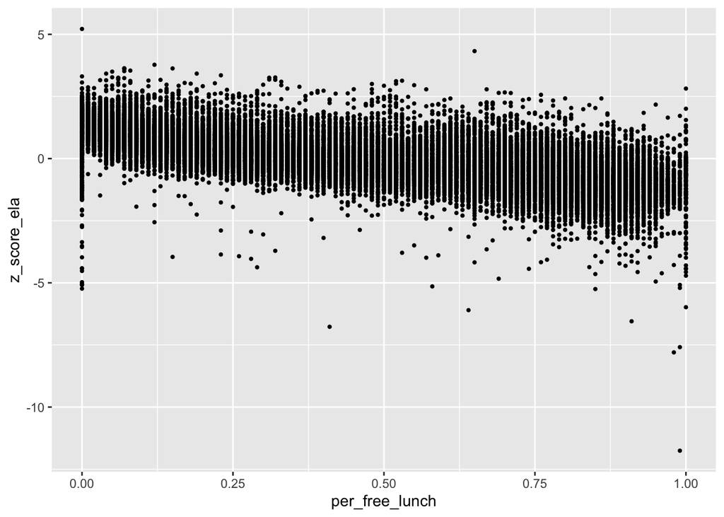

```r
library(ggplot2)

# Create a scatterplot with the per_free_lunch on the x-axis and ELA test score on the y-axis
schools %>%
    ggplot() +
    geom_point(aes(x=per_free_lunch, y=z_score_ela), size=0.75, fill="black") +
    # Limit the viewing range of per_free_lunch from 0% to 100%
    xlim(0,1)
```

For Math test scores:

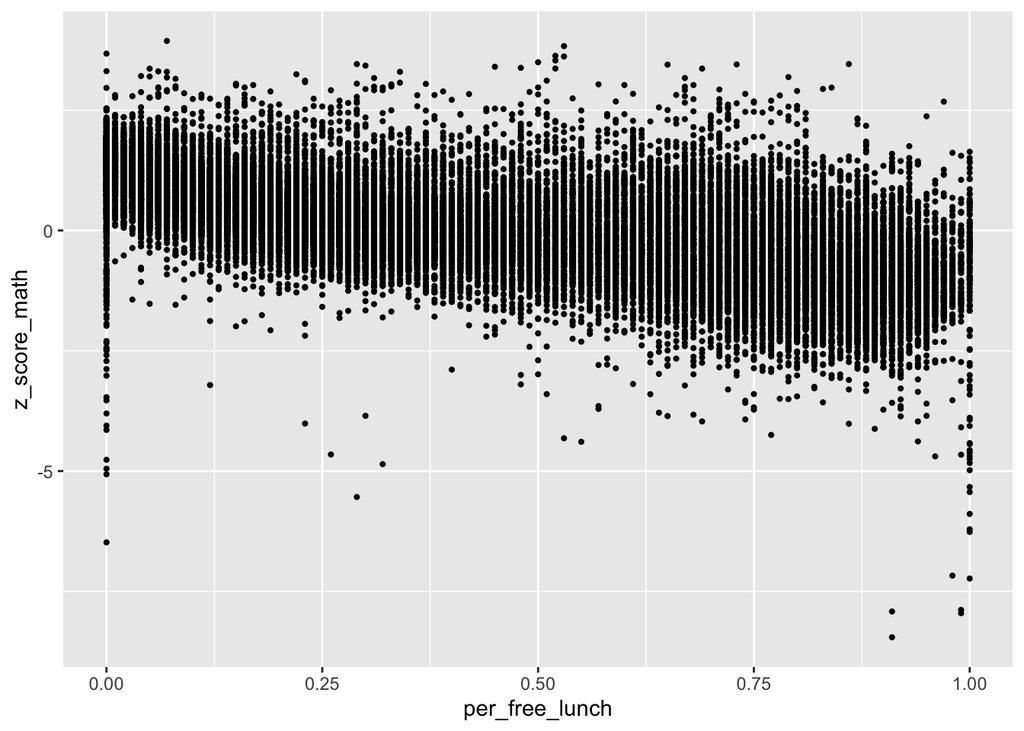

```r
# Create a scatterplot with the per_free_lunch on the x-axis and Math test score on the y-axis
schools %>%
    ggplot() +
    geom_point(aes(x=per_free_lunch, y=z_score_math), size=0.75, fill="black") +
    # Limit the viewing range of per_free_lunch from 0% to 100%
    xlim(0,1)
```

**2. Average test performance across counties with high, low, and medium poverty.**

For ELA:

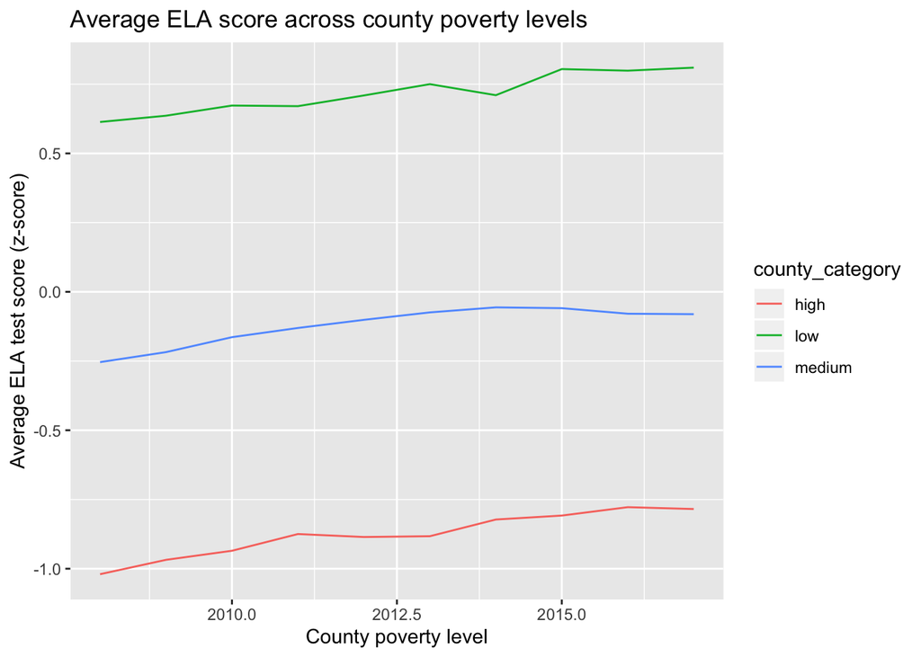

```r
# Average test scores for ELA
schools %>%
    # omit the NAs in the county_category
    na.omit(county_category) %>%
    # group by county_category and year to get the average scores by county category and year
    group_by(county_category, year) %>%
    summarize(avg_ela_score=mean(z_score_ela, na.rm=TRUE)) %>%
    ggplot() +
    geom_line(aes(x=year, y=avg_ela_score, group=county_category, col=county_category)) +
    labs(title="Average ELA score across county poverty levels",
         x="County poverty level",
         y="Average ELA test score (z-score)")
```

For Math:

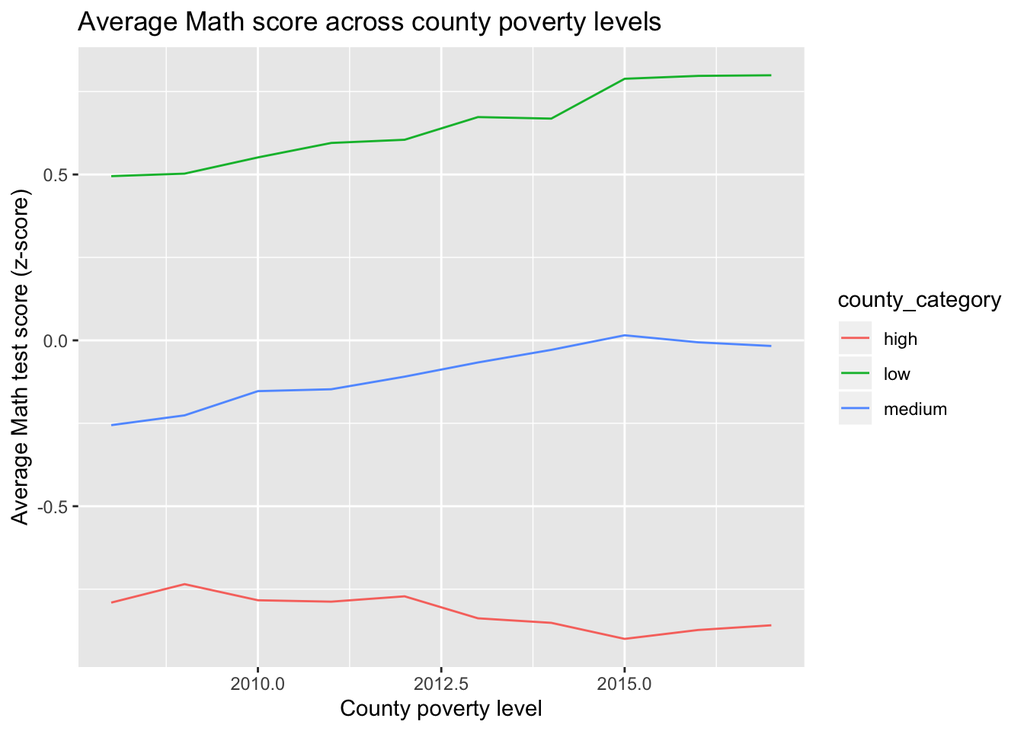

```r
# Average test scores for Math
schools %>%
    # omit the NAs in the county_category
    na.omit(county_category) %>%
    # group by county_category and year to get the average scores by year
    group_by(county_category, year) %>%
    summarize(avg_math_score=mean(z_score_math, na.rm=TRUE)) %>%
    ggplot() +
    geom_line(aes(x=year, y=avg_math_score, group=county_category, col=county_category)) +
    labs(title="Average Math score across county poverty levels",
         x="County poverty level",
         y="Average Math test score (z-score)")
```

### Task 7: Answering questions

**Using the skills you have learned in the past three days, tackle the following question:**

*What can the data tell us about the relationship between poverty and test performance in New York public schools? Has this relationship changed over time? Is this relationship at all moderated by access to free/reduced price lunch?*

*You may use summary tables, statistical models, and/or data visualization in pursuing an answer to this question. Feel free to build on the tables and plots you generated above in Tasks 5 and 6.*

From the visualization in question 6.2, we can clearly see that the poverty level of a county does correlate with the average math and ELA test scores, as anticipated. The highest poverty areas have the lowest test scores, while the lowest poverty areas have the highest test scores. While average test scores across all counties seem to be increasing over time, the one exception is math scores for high poverty areas, which appeared to decline overall over the past few years.

We can also run a linear regression on each of the test scores as a function of the remaining numerical variables, using the county-level data.

```r
# Perform linear regression for ELA scores
reg_ela <- lm(mean_ela_score ~ per_free_lunch + total_enroll + county_per_poverty + median_household_income + county_per_bach, data=county_df)

summary(reg_ela)
```

```
##
## Call:
## lm(formula = mean_ela_score ~ per_free_lunch + total_enroll +
##     county_per_poverty + median_household_income + county_per_bach,
##     data = county_df)
##
## Residuals:
##      Min       1Q   Median       3Q      Max
## -0.35306 -0.11504 -0.00687  0.11741  0.29253
##
## Coefficients:
##                           Estimate Std. Error t value Pr(>|t|)
## (Intercept)              4.375e-01  2.491e-01   1.756 0.084522 .
## per_free_lunch          -1.528e+00  4.209e-01  -3.630 0.000616 ***
## total_enroll             2.009e-07  6.498e-08   3.092 0.003095 **
## county_per_poverty      -1.806e+00  1.172e+00  -1.541 0.128883
## median_household_income  1.477e-06  3.412e-06   0.433 0.666766
## county_per_bach          1.335e+00  7.229e-01   1.847 0.070094 .
## ---
## Signif. codes:  0 '***' 0.001 '**' 0.01 '*' 0.05 '.' 0.1 ' ' 1
##
## Residual standard error: 0.1524 on 56 degrees of freedom
## Multiple R-squared:  0.7493, Adjusted R-squared:  0.7269
## F-statistic: 33.48 on 5 and 56 DF,  p-value: 1.175e-15
```

```r
# Perform linear regression for math scores
reg_math <- lm(mean_math_score ~ per_free_lunch + total_enroll + county_per_poverty + median_household_income + county_per_bach, data=county_df)

summary(reg_math)
```

```
##
## Call:
## lm(formula = mean_math_score ~ per_free_lunch + total_enroll +
##     county_per_poverty + median_household_income + county_per_bach,
##     data = county_df)
##
## Residuals:
##      Min       1Q   Median       3Q      Max
## -0.29077 -0.13597  0.00953  0.11309  0.33687
##
## Coefficients:
##                           Estimate Std. Error t value Pr(>|t|)
## (Intercept)              2.655e-01  2.597e-01   1.022   0.3110
## per_free_lunch          -9.217e-01  4.388e-01  -2.101   0.0402 *
## total_enroll             1.709e-07  6.773e-08   2.523   0.0145 *
## county_per_poverty      -2.240e+00  1.221e+00  -1.834   0.0719 .
## median_household_income  3.320e-06  3.556e-06   0.934   0.3545
## county_per_bach          6.447e-01  7.535e-01   0.856   0.3959
## ---
## Signif. codes:  0 '***' 0.001 '**' 0.01 '*' 0.05 '.' 0.1 ' ' 1
##
## Residual standard error: 0.1589 on 56 degrees of freedom
## Multiple R-squared:  0.6691, Adjusted R-squared:  0.6395
## F-statistic: 22.64 on 5 and 56 DF,  p-value: 2.383e-12
```

We can also run a T-test to check that the differences in mean test scores across the “high poverty” and “low poverty” counties are statistically significant.

```r
# Create a variable that is an indicator of whether the county is a "high" or "low" poverty area
county_df_reduced$per_pov_highLow <- NA

county_df_reduced$per_pov_highLow[county_df_reduced$county_per_poverty >= per_poverty_high] <- "High"
county_df_reduced$per_pov_highLow[county_df_reduced$county_per_poverty <= per_poverty_low] <- "Low"
```

```r
# Run the t-test on both ELA and math scores
t.test(county_df_reduced$mean_ela_score~county_df_reduced$per_pov_highLow)
```

```
##
##  Welch Two Sample t-test
##
## data:  county_df_reduced$mean_ela_score by county_df_reduced$per_pov_highLow
## t = -4.4166, df = 7.9965, p-value = 0.002239
## alternative hypothesis: true difference in means is not equal to 0
## 95 percent confidence interval:
##  -1.3190963 -0.4140945
## sample estimates:
## mean in group High  mean in group Low
##         -0.3401636          0.5264318
```

```r
t.test(county_df_reduced$mean_math_score~county_df_reduced$per_pov_highLow)
```

```
##
##  Welch Two Sample t-test
##
## data:  county_df_reduced$mean_math_score by county_df_reduced$per_pov_highLow
## t = -3.8751, df = 7.6787, p-value = 0.005093
## alternative hypothesis: true difference in means is not equal to 0
## 95 percent confidence interval:
##  -1.1921444 -0.2985575
## sample estimates:
## mean in group High  mean in group Low
##         -0.3016049          0.4437461
```

**Given the short time period, any answer will of course prove incomplete. The goal of this task is to give you some room to play around with the skills you’ve just learned. Don’t hesitate to try something even if you don’t feel comfortable with it yet. Do as much as you can in the time allotted.**